# Pracical Mahine Learning: Course Project

Fabiola

9/22/2020

# Project description

Using devices such as Jawbone Up, Nike FuelBand, and Fitbit is now possible to collect a large amount of data about personal activity relatively inexpensively. These type of devices are part of the quantified self movement – a group of enthusiasts who take measurements about themselves regularly to improve their health, to find patterns in their behavior, or because they are tech geeks. One thing that people regularly do is quantify how much of a particular activity they do, but they rarely quantify how well they do it.

In this project, we will use data from accelerometers on the belt, forearm, arm, and dumbell of 6 participants. They were asked to perform barbell lifts correctly and incorrectly in 5 different ways. The five ways are exactly according to the specification (Class A), throwing the elbows to the front (Class B), lifting the dumbbell only halfway (Class C), lowering the dumbbell only halfway (Class D) and throwing the hips to the front (Class E). Only Class A corresponds to correct performance. The goal of this project is to predict the manner in which they did the exercise (Clss A-E). More information is available from the website here: http://groupware.les.inf.puc-rio.br/har (see Weight Lifting Exercise Dataset section).

# Loading of libraries

```r
library(caret)
library(rattle)
library(rpart)
library(randomForest)
```

```r
library(corrplot)
library(e1071)
library(gbm)
```

# Data Processing

After having loaded the necessary libraries, we read in the csv files with the training and testing data. The training dataset was originally composed of 160 variables and 19622 observations, and the testing dataset was composed of 160 variables and 20 observations. We noticed that the first 7 variables were timestamps, and thus not relevant to our analysis, as well as that many variables had mostly observations with NA values. We excluded these variables from our train and test datasets, leaving only 53 variables in both the train and test datasets. We then proceded to further partition the training dataset into a training and a cross-validation set in order to get out of sample errors and prevent over-fitting (using a 60-40 ratio).

```r
# read data
data = read.csv("pml-training.csv", na.strings=c("NA","#DIV/0!", ""))
str(data); dim(data)
```

```
## 'data.frame':    19622 obs. of  160 variables:
##  $ X                       : int  1 2 3 4 5 6 7 8 9 10 ...
##  $ user_name               : chr  "carlitos" "carlitos" "carlitos" "carlitos" ...
##  $ raw_timestamp_part_1    : int  1323084231 1323084231 1323084231 1323084232 1323084232 1323084232 1323084232 1323084232 1323084232 1323084232 ...
##  $ raw_timestamp_part_2    : int  788290 808298 820366 120339 196328 304277 368296 440390 484323 484434 ...
##  $ cvtd_timestamp          : chr  "05/12/2011 11:23" "05/12/2011 11:23" "05/12/2011 11:23" "05/12/2011 11:23" ...
##  $ new_window              : chr  "no" "no" "no" "no" ...
##  $ num_window              : int  11 11 11 12 12 12 12 12 12 12 ...
##  $ roll_belt               : num  1.41 1.41 1.42 1.48 1.48 1.45 1.42 1.42 1.43 1.45 ...
##  $ pitch_belt              : num  8.07 8.07 8.07 8.05 8.07 8.06 8.09 8.13 8.16 8.17 ...
##  $ yaw_belt                : num  -94.4 -94.4 -94.4 -94.4 -94.4 -94.4 -94.4 -94.4 -94.4 -94.4 ...
##  $ total_accel_belt        : int  3 3 3 3 3 3 3 3 3 3 ...
##  $ kurtosis_roll_belt      : num  NA NA NA NA NA NA NA NA NA NA ...
##  $ kurtosis_picth_belt     : num  NA NA NA NA NA NA NA NA NA NA ...
##  $ kurtosis_yaw_belt       : logi  NA NA NA NA NA NA ...
```

[output cut: 86 more lines]

```
## [1] 19622   160
```

```r
testData = read.csv("pml-testing.csv", na.strings=c("NA","#DIV/0!", ""))
head(testData); dim(testData)
```

```
##   X user_name raw_timestamp_part_1 raw_timestamp_part_2   cvtd_timestamp
## 1 1     pedro           1323095002               868349 05/12/2011 14:23
## 2 2    jeremy           1322673067               778725 30/11/2011 17:11
## 3 3    jeremy           1322673075               342967 30/11/2011 17:11
## 4 4    adelmo           1322832789               560311 02/12/2011 13:33
## 5 5    eurico           1322489635               814776 28/11/2011 14:13
## 6 6    jeremy           1322673149               510661 30/11/2011 17:12
##   new_window num_window roll_belt pitch_belt yaw_belt total_accel_belt
## 1         no         74    123.00      27.00    -4.75               20
## 2         no        431      1.02       4.87   -88.90                4
## 3         no        439      0.87       1.82   -88.50                5
## 4         no        194    125.00     -41.60   162.00               17
## 5         no        235      1.35       3.33   -88.60                3
## 6         no        504     -5.92       1.59   -87.70                4
##   kurtosis_roll_belt kurtosis_picth_belt kurtosis_yaw_belt skewness_roll_belt
```

[output cut: 251 more lines]

```
## [1]  20 160
```

```r
# clean out variables with NA values
# and columns not relevant to motion
data = data[,colSums(is.na(data))==0]
data = data[,-c(1:7)]
dim(data); names(data)
```

```
## [1] 19622    53
```

```
##  [1] "roll_belt"            "pitch_belt"           "yaw_belt"
##  [4] "total_accel_belt"     "gyros_belt_x"         "gyros_belt_y"
##  [7] "gyros_belt_z"         "accel_belt_x"         "accel_belt_y"
## [10] "accel_belt_z"         "magnet_belt_x"        "magnet_belt_y"
## [13] "magnet_belt_z"        "roll_arm"             "pitch_arm"
## [16] "yaw_arm"              "total_accel_arm"      "gyros_arm_x"
## [19] "gyros_arm_y"          "gyros_arm_z"          "accel_arm_x"
## [22] "accel_arm_y"          "accel_arm_z"          "magnet_arm_x"
## [25] "magnet_arm_y"         "magnet_arm_z"         "roll_dumbbell"
## [28] "pitch_dumbbell"       "yaw_dumbbell"         "total_accel_dumbbell"
## [31] "gyros_dumbbell_x"     "gyros_dumbbell_y"     "gyros_dumbbell_z"
## [34] "accel_dumbbell_x"     "accel_dumbbell_y"     "accel_dumbbell_z"
## [37] "magnet_dumbbell_x"    "magnet_dumbbell_y"    "magnet_dumbbell_z"
## [40] "roll_forearm"         "pitch_forearm"        "yaw_forearm"
## [43] "total_accel_forearm"  "gyros_forearm_x"      "gyros_forearm_y"
## [46] "gyros_forearm_z"      "accel_forearm_x"      "accel_forearm_y"
## [49] "accel_forearm_z"      "magnet_forearm_x"     "magnet_forearm_y"
## [52] "magnet_forearm_z"     "classe"
```

```r
testData = testData[,colSums(is.na(testData))==0]
testData = testData[,-c(1:7)]
dim(testData); names(testData)
```

```
## [1] 20 53
```

```
##  [1] "roll_belt"            "pitch_belt"           "yaw_belt"
##  [4] "total_accel_belt"     "gyros_belt_x"         "gyros_belt_y"
##  [7] "gyros_belt_z"         "accel_belt_x"         "accel_belt_y"
## [10] "accel_belt_z"         "magnet_belt_x"        "magnet_belt_y"
## [13] "magnet_belt_z"        "roll_arm"             "pitch_arm"
## [16] "yaw_arm"              "total_accel_arm"      "gyros_arm_x"
## [19] "gyros_arm_y"          "gyros_arm_z"          "accel_arm_x"
## [22] "accel_arm_y"          "accel_arm_z"          "magnet_arm_x"
## [25] "magnet_arm_y"         "magnet_arm_z"         "roll_dumbbell"
## [28] "pitch_dumbbell"       "yaw_dumbbell"         "total_accel_dumbbell"
## [31] "gyros_dumbbell_x"     "gyros_dumbbell_y"     "gyros_dumbbell_z"
## [34] "accel_dumbbell_x"     "accel_dumbbell_y"     "accel_dumbbell_z"
## [37] "magnet_dumbbell_x"    "magnet_dumbbell_y"    "magnet_dumbbell_z"
## [40] "roll_forearm"         "pitch_forearm"        "yaw_forearm"
## [43] "total_accel_forearm"  "gyros_forearm_x"      "gyros_forearm_y"
## [46] "gyros_forearm_z"      "accel_forearm_x"      "accel_forearm_y"
## [49] "accel_forearm_z"      "magnet_forearm_x"     "magnet_forearm_y"
## [52] "magnet_forearm_z"     "problem_id"
```

```r
# partition training and cv dataset
set.seed(4444)
inTrain = createDataPartition(data$classe, p=.6, list=FALSE)
dataTrain = data[inTrain,]
dataTest = data[-inTrain,]
dim(dataTrain)
```

```
## [1] 11776    53
```

# Testing different models

We then continued by testing three different machine learning models (classification tree, random forest, gradient boosting method) to test accuracy in predicting the “classe” variable.

## 1. Classification tree

We began our model analysis by using the classification tree model (we set k=5 in our k-fold cross-validation). The results of this first model (accuracy = 0.55) seem to indicate that a classification tree is not the optimal model for predicting “classe” with this dataset.

```r
control = trainControl(method="cv", number=5)
mdlCT = train(classe~., data=dataTrain, method="rpart", trControl=control)
print(mdlCT, digits=4)
```

```
## CART
##
## 11776 samples
##    52 predictor
##     5 classes: 'A', 'B', 'C', 'D', 'E'
##
## No pre-processing
## Resampling: Cross-Validated (5 fold)
## Summary of sample sizes: 9420, 9421, 9422, 9420, 9421
## Resampling results across tuning parameters:
##
##   cp       Accuracy  Kappa
##   0.02765  0.5448    0.41563
##   0.04245  0.5102    0.36964
##   0.11521  0.3154    0.04751
##
## Accuracy was used to select the optimal model using the largest value.
## The final value used for the model was cp = 0.02765.
```

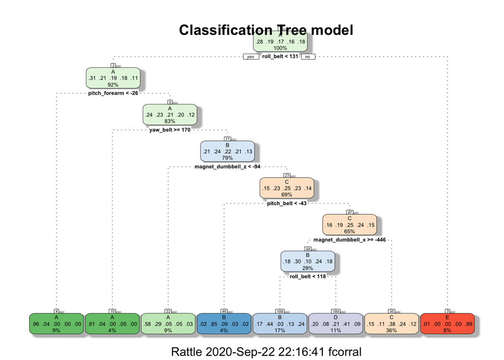

```r
fancyRpartPlot(mdlCT$finalModel, main = "Classification Tree model")
```

```r
predCT = predict(mdlCT, dataTest)
confusionMatrix(as.factor(dataTest$classe), predCT)$table
```

```
##           Reference
## Prediction    A    B    C    D    E
##          A 1404  216  454  153    5
##          B  265  846  324   83    0
##          C   32   58 1096  182    0
##          D   67  186  676  357    0
##          E   21  365  324   81  651
```

```r
confusionMatrix(as.factor(dataTest$classe), predCT)$overall[1]
```

```
##  Accuracy
## 0.5549324
```

# 2. Random forest

```r
mdlRF = train(classe~., data=dataTrain, method="rf", trControl=control, verbose=FALSE)
print(mdlRF, digits=4)
```

```
## Random Forest
##
## 11776 samples
##    52 predictor
##     5 classes: 'A', 'B', 'C', 'D', 'E'
##
## No pre-processing
## Resampling: Cross-Validated (5 fold)
## Summary of sample sizes: 9421, 9422, 9421, 9420, 9420
## Resampling results across tuning parameters:
##
##   mtry  Accuracy  Kappa
##    2    0.9900    0.9873
##   27    0.9894    0.9866
##   52    0.9858    0.9821
##
## Accuracy was used to select the optimal model using the largest value.
## The final value used for the model was mtry = 2.
```

```r
names(mdlRF$finalModel)
```

```
##  [1] "call"            "type"            "predicted"       "err.rate"
##  [5] "confusion"       "votes"           "oob.times"       "classes"
##  [9] "importance"      "importanceSD"    "localImportance" "proximity"
## [13] "ntree"           "mtry"            "forest"          "y"
## [17] "test"            "inbag"           "xNames"          "problemType"
## [21] "tuneValue"       "obsLevels"       "param"
```

```r
varImp(mdlRF)
```

```
## rf variable importance
##
##   only 20 most important variables shown (out of 52)
##
##                      Overall
## roll_belt             100.00
## yaw_belt               80.11
## magnet_dumbbell_z      68.21
## pitch_belt             63.83
## pitch_forearm          60.84
## magnet_dumbbell_y      60.01
## magnet_dumbbell_x      53.16
## roll_forearm           50.87
## accel_belt_z           49.34
## magnet_belt_z          46.22
## roll_dumbbell          45.88
## accel_dumbbell_y       43.23
## magnet_belt_y          40.74
## accel_dumbbell_z       40.00
## roll_arm               35.61
## accel_forearm_x        33.54
## gyros_belt_z           30.38
## magnet_arm_x           30.24
## total_accel_dumbbell   29.88
## yaw_dumbbell           29.63
```

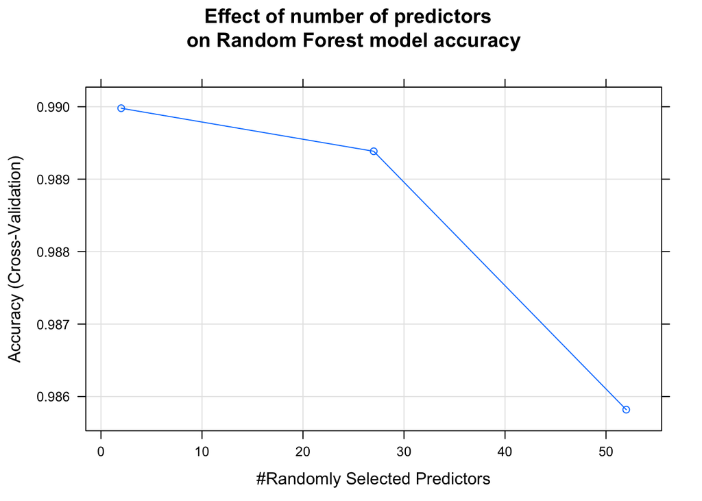

```r
par(mfrow=c(1,2))
plot(mdlRF, main="Effect of number of predictors \n on Random Forest model accuracy")
```

```r
plot(mdlRF$finalModel, main="Class error \n by number of trees on RF model")
predRF = predict(mdlRF, dataTest)
confusionMatrix(as.factor(dataTest$classe), predRF)$table
```

```
##           Reference
## Prediction    A    B    C    D    E
##          A 2230    2    0    0    0
##          B   19 1485   14    0    0
##          C    0    8 1358    2    0
##          D    0    0   46 1236    4
##          E    0    0    2    2 1438
```

```r
confusionMatrix(as.factor(dataTest$classe), predRF)$overall[1]
```

```
##  Accuracy
## 0.9873821
```

[figure not shown]

# 3. Gradient boosting method

Finally, we modeled “classe” using the Gradient boosting method, which is another method for creating an ensemble of machine learning models, but one which uses a variety of models, not just decision trees. Although the resulting accuracy (.95) is not as high as Random forest, it is still very high, suggesting the GBM could also be a good method for predicting the “classe” variable.

```r
mdlGBM = train(classe~., data=dataTrain, method="gbm", trControl=control, verbose=FALSE)
print(mdlGBM, digits=4)
```

```
## Stochastic Gradient Boosting
##
## 11776 samples
##    52 predictor
##     5 classes: 'A', 'B', 'C', 'D', 'E'
##
## No pre-processing
## Resampling: Cross-Validated (5 fold)
## Summary of sample sizes: 9421, 9421, 9420, 9422, 9420
## Resampling results across tuning parameters:
##
##   interaction.depth  n.trees  Accuracy  Kappa
##   1                   50      0.7525    0.6861
##   1                  100      0.8218    0.7745
##   1                  150      0.8549    0.8164
##   2                   50      0.8571    0.8190
##   2                  100      0.9072    0.8825
##   2                  150      0.9332    0.9154
##   3                   50      0.8971    0.8697
##   3                  100      0.9407    0.9250
##   3                  150      0.9595    0.9488
##
## Tuning parameter 'shrinkage' was held constant at a value of 0.1
##
## Tuning parameter 'n.minobsinnode' was held constant at a value of 10
## Accuracy was used to select the optimal model using the largest value.
## The final values used for the model were n.trees = 150, interaction.depth =
##  3, shrinkage = 0.1 and n.minobsinnode = 10.
```

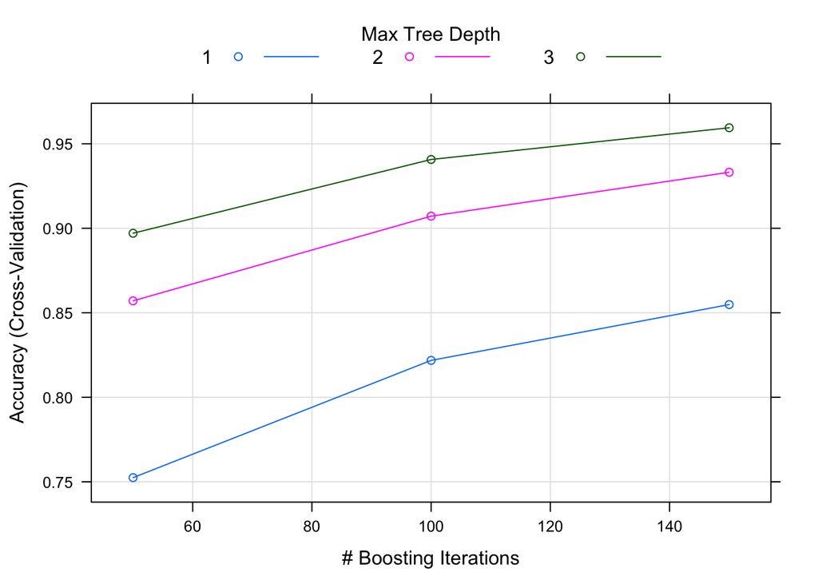

```r
par(mfrow=c(1,1))
plot(mdlGBM)
```

```r
predGBM = predict(mdlGBM, dataTest)
confusionMatrix(as.factor(dataTest$classe), predGBM)$table
```

```
##           Reference
## Prediction    A    B    C    D    E
##          A 2190   24   11    6    1
##          B   59 1402   49    1    7
##          C    0   34 1316   16    2
##          D    1    4   53 1217   11
##          E    0   21   12   20 1389
```

```r
confusionMatrix(as.factor(dataTest$classe), predGBM)$overall[1]
```

```
##  Accuracy
## 0.9576854
```

# Final testing

Since the Random forest model resulted in the highest accuracy, we will use it to predict the “classe” variable in the test dataset.

```r
predict(mdlRF, testData)
```

```
##  [1] B A B A A E D B A A B C B A E E A B B B
## Levels: A B C D E
```